# Taller 3 - Maestria en Matemáticas Aplicadas y Ciencias de la Computación

Jorge Esneider Henao - Diego Alberto Rodríguez Cruz - Hector Leandro Rojas

2023-05-22

# Dependencias

- ´install.packages(“tibble”)´
- ´install.packages(“ggplot2”)´
- ´install.packages(“reshape2”)´
- ´install.packages(“readxl”)´
- ´install.packages(“ROCR”)´
- ´install.packages(“RODBC”)´
- ´install.packages(“mice”)´
- ´install.packages(“mclust”)´
- ´install.packages(“MASS”)´

# Librerías

```r
#Carga de librerias
library(tibble)
library(ggplot2)
library(reshape2)
library(readxl)
library(ROCR)
library(RODBC)
library(mice)
library(mclust)
library(MASS)
```

# Variable(s) Global(es)

```r
#Definicion del valor de la semilla global
semilla <- 123
```

# Problema 1

Una familia de distribuciones P$_\theta$ con $\theta$ $\in$ $\Theta$ pertenece a la familia exponencial de distribucciones si su $\frac{fmp}{fdp}$ puede escribirse como: $p(x|\eta) = h(x)exp(\eta(\theta)t(x)-\alpha(\theta)$

Para funciones reales $h(x)$, $\alpha(\theta)$ y $t(x)$. Muestre que tanto la distribución bernoulli (utilizada para la regresión logística), la distribución normal (utilizada en la regresión lineal) y la distribución Poisson (utilizada en la regresión Poisson sobre conteos) pertenecen a esta familia de distribuciones.

**Respuesta**

En cuanto a las distribuciones que pertenecen a la familia exponencial se denomina familia exponencial de un parámetro si se tiene o existen funciones de la forma

$$p = { p\_{\theta}: \theta \in \Theta
}$$

será denominado de la familia exponencial si existe un parámetro

$$c(\theta), d(\theta), \theta \in
\Theta$$

De tal forma que la función de densidad o de probabilidad $p(\tilde{x},\theta)$ puede ser discreta de la siguiente forma

$$p(\tilde{x},\theta) = \exp\left\{
c(\theta)T(\tilde{x})+d(\theta)+s(\tilde{x}) \right\} \cdot
I_G(\tilde{x})$$

Donde $I_G(\tilde{x})$ es una función indicadora de G:

$$I_G(\tilde{x}) = \begin{cases} 1 &
\text{si } x \leq 0 \\ 0 & \text{en otro caso}
\end{cases}$$

En la familia exponencial, $T(\tilde{x})$ es un estadístico suficiente y completo. La suficiencia de $T(\tilde{x})$ con recorrido en $I = R_T$ para $\theta$ se da solo si existe una función $g(t,\tilde{\theta})$, $t \in I$, $\theta \in \Theta$, y una función $h(\tilde{x})$, $x \in \mathbb{R}^n$, tales que se toman como, (A, R. H., M, A. M., & C, D. M. (2012)) :

$$p(\tilde{x},\tilde{\theta}) =
g(T(\tilde{x}),\tilde{\theta}) \cdot h(\tilde{x})$$

Para la función Poisson, si una variable aleatoria se distribuye denotada como $Y \sim \text{Pois}(\lambda)$, su función de probabilidad es:

$$f(y;\lambda)=
\frac{\lambda^ye^{-\lambda}}{y!} = \exp(y \log \lambda - \lambda -
y!)$$

se dice por tanto que

$\alpha(y) = y, b(\lambda) = \log\lambda, c(\lambda) = -\lambda$ y $d(y) = \log y!$

también a su vez concluyendo que esta distribucion pertenece a la famila exponencial

Para la distribución normal, tenemos que si una variable aleatoria se distribuye como una normal $Y \sim N(\mu,\sigma^2)$, sea $\theta = (\mu,\sigma)$, su función de densidad es:

$$f(y;\theta) = \frac{1}{\sqrt{2\pi\sigma} } \exp(
-\frac{1}{2}(\frac{y-\mu}{\sigma})^2)
\\=\exp(-\frac{1}{2\sigma^2}y^2 + \frac{\mu}{\sigma^2}y -
\frac{\mu^2}{2\sigma^2} + \log (\frac{1}{\sqrt{2\pi\sigma} }))$$

de ahi se tiene que

$$\alpha(y) = (a_1(y),a_2(y)) = (y^2,y),
\\b(\theta) = (b_1(\theta),b_2(\theta)) =
(-\frac{1}{2\sigma^2},\frac{\mu}{\sigma^2}),
\\c(\theta) = -\frac{\mu^2}{2\sigma^2} + \log
(\frac{1}{\sqrt{2\pi\sigma}}) ,
\\d(y) = 0$$

tambien a su vez concluyendo que esta distribucion normal pertenece a la famila exponencial

Respecto a Bernoulli Una variable aleatoria de Bernoulli $X$ asigna una medida de probabilidad $\pi$ al punto $x = 1$ y medida de probabilidad $1 - \pi$ al punto $x = 0$. Más formalmente, se define como la medida de conteo en $\{0, 1\}$, y se define la siguiente función de densidad con respecto a la medida $v$ Jordan(2009):

$$p(x|\pi) = \pi^x(1-\pi)^{1-x}
\\= \exp\{ \log (\frac{\pi}{1-\pi}) x + \log (1 - \pi )\}$$

para revelar o encontrar su forma canonica como parte de la familia exponencial tomamos es tomar la exponencial del logaritmo de la forma “usual” de la densidad, por tanto

$$\eta = \frac{\pi}{1-\pi}
\\T=x
\\A(\eta) = -\log(1-\pi) = \log(1+e^\eta)
\\h(x) = 1$$

de donde tenemos que para n

$$\pi = \frac{1}{1+e^{-n}}, \text {que no es más que la función logística}$$

# Problema 2

La Universidad de California Irvine (UCI) tiene un repositorio de datos de ejemplo para el uso de machine learning y aprendizaje estadístico. Uno de los conjuntos de datos es el denominado Heart Disease, su descripción detallada se encuentra en la URL a continuación: https://archive.ics.uci.edu/ml/datasets/Heart+Disease

Como podrá ver, estos datos se encuentran disponibles para su uso en la siguiente URL: https://archive.ics.uci.edu/ml/machine-learning-databases/heart-disease/

Utilice los datos procesados disponibles en el enlace presentado a continuación para el desarrollo del ejercicio,

http://archive.ics.uci.edu/ml/machine-learning-databases/heart-disease/processed.cleveland.data

Con el conjunto de datos completo, construya un modelo de regresión logístico con función de enlace logit tomando como respuesta la presencia de la enfermedad cardiaca, use las demás variables como explicativas en el modelo de regresión. Revise las URL dadas para la definición de cada una de las variables y note que debe obtener la variable respuesta categorizando una de las variables del conjunto de datos. Siga los siguientes pasos en la realización del ejercicio:

```r
set.seed(semilla)

#carga de datos
data <- read.csv('processed.cleveland.data',na= '?', sep=",", header = FALSE)
```

```r
set.seed(semilla)

#Asignación de Nombres de columnas
nombre_columna <- c("age","sex","cp ","trestbps","chol","fbs","restecg","thalach","exang","oldpeak","slope","ca","thal","num")

colnames(data)<-nombre_columna

dataSinTransformar <- data
```

```r
set.seed(semilla)

#Visualización 10 registros de los datos cargados
head(data,10)
```

```
##    age sex cp  trestbps chol fbs restecg thalach exang oldpeak slope ca thal
## 1   63   1   1      145  233   1       2     150     0     2.3     3  0    6
## 2   67   1   4      160  286   0       2     108     1     1.5     2  3    3
## 3   67   1   4      120  229   0       2     129     1     2.6     2  2    7
## 4   37   1   3      130  250   0       0     187     0     3.5     3  0    3
## 5   41   0   2      130  204   0       2     172     0     1.4     1  0    3
## 6   56   1   2      120  236   0       0     178     0     0.8     1  0    3
## 7   62   0   4      140  268   0       2     160     0     3.6     3  2    3
## 8   57   0   4      120  354   0       0     163     1     0.6     1  0    3
## 9   63   1   4      130  254   0       2     147     0     1.4     2  1    7
## 10  53   1   4      140  203   1       2     155     1     3.1     3  0    7
##    num
## 1    0
## 2    2
## 3    1
## 4    0
## 5    0
## 6    0
## 7    3
## 8    0
## 9    2
## 10   1
```

```r
set.seed(semilla)

# Resumen estadistico de los datos
summary(data)
```

```
##       age             sex              cp            trestbps
##  Min.   :29.00   Min.   :0.0000   Min.   :1.000   Min.   : 94.0
##  1st Qu.:48.00   1st Qu.:0.0000   1st Qu.:3.000   1st Qu.:120.0
##  Median :56.00   Median :1.0000   Median :3.000   Median :130.0
##  Mean   :54.44   Mean   :0.6799   Mean   :3.158   Mean   :131.7
##  3rd Qu.:61.00   3rd Qu.:1.0000   3rd Qu.:4.000   3rd Qu.:140.0
##  Max.   :77.00   Max.   :1.0000   Max.   :4.000   Max.   :200.0
##
##       chol            fbs            restecg          thalach
##  Min.   :126.0   Min.   :0.0000   Min.   :0.0000   Min.   : 71.0
##  1st Qu.:211.0   1st Qu.:0.0000   1st Qu.:0.0000   1st Qu.:133.5
##  Median :241.0   Median :0.0000   Median :1.0000   Median :153.0
##  Mean   :246.7   Mean   :0.1485   Mean   :0.9901   Mean   :149.6
##  3rd Qu.:275.0   3rd Qu.:0.0000   3rd Qu.:2.0000   3rd Qu.:166.0
##  Max.   :564.0   Max.   :1.0000   Max.   :2.0000   Max.   :202.0
##
##      exang           oldpeak         slope             ca
##  Min.   :0.0000   Min.   :0.00   Min.   :1.000   Min.   :0.0000
##  1st Qu.:0.0000   1st Qu.:0.00   1st Qu.:1.000   1st Qu.:0.0000
##  Median :0.0000   Median :0.80   Median :2.000   Median :0.0000
##  Mean   :0.3267   Mean   :1.04   Mean   :1.601   Mean   :0.6722
##  3rd Qu.:1.0000   3rd Qu.:1.60   3rd Qu.:2.000   3rd Qu.:1.0000
##  Max.   :1.0000   Max.   :6.20   Max.   :3.000   Max.   :3.0000
##                                                  NA's   :4
##       thal            num
##  Min.   :3.000   Min.   :0.0000
##  1st Qu.:3.000   1st Qu.:0.0000
##  Median :3.000   Median :0.0000
##  Mean   :4.734   Mean   :0.9373
##  3rd Qu.:7.000   3rd Qu.:2.0000
##  Max.   :7.000   Max.   :4.0000
##  NA's   :2
```

```r
set.seed(semilla)

# Cantidad de columnas y filas
cat ('Cantidad Columnas ',ncol(data),'\n')
```

```
## Cantidad Columnas  14
```

```r
cat ('Cantidad Filas ',nrow(data),'\n')
```

```
## Cantidad Filas  303
```

```r
set.seed(semilla)

#Cantidad de nulos/NA en el conjunto de datos
sum(is.na(data))
```

```
## [1] 6
```

```r
set.seed(semilla)

#Ubicacion de los valores nulos en las columnas
sapply(data, function(x)sum(is.na(x)))
```

```
##      age      sex      cp  trestbps     chol      fbs  restecg  thalach
##        0        0        0        0        0        0        0        0
##    exang  oldpeak    slope       ca     thal      num
##        0        0        0        4        2        0
```

```r
set.seed(semilla)

#Conversión a factor, con el fin de trabajar con variables categoricas y nominales
data$age <- as.numeric(data$age)
data$sex <- factor(data$sex, levels = c(0, 1), labels = c("F", "M"))
data$trestbps <- as.numeric(data$trestbps)
data$chol <- as.numeric(data$chol)
data$fbs <- factor(data$fbs, levels = c(0, 1), labels = c("False", "True"))
data$restecg <- factor(data$restecg)
data$thalach <- as.numeric(data$thalach)
data$exang <- factor(data$exang, levels = c(0, 1), labels = c("False", "True"))
data$oldpeak <- as.numeric(data$oldpeak)
data$slope <- factor(data$slope)
data$ca <- factor(data$ca)
data$thal <- factor(data$thal)
data$num <- ifelse(data$num == 0, "Healthy", "Unhealthy")
```

## Punto 1: Imputar datos:

```r
set.seed(semilla)

data <- data.frame(apply(data, 2, function(x) ifelse(is.na(x), median(x, na.rm = TRUE), x)))
```

```r
set.seed(semilla)

data$age <- as.numeric(data$age)
data$sex <- as.factor(data$sex)
data$trestbps <- as.numeric(data$trestbps)
data$chol <- as.numeric(data$chol)
data$fbs <- as.factor(data$fbs)
data$restecg <- as.factor(data$restecg)
data$thalach <- as.numeric(data$thalach)
data$exang <- as.factor(data$exang)
data$oldpeak <- as.numeric(data$oldpeak)
data$slope <- as.factor(data$slope)
data$ca <- as.factor(data$ca)
data$thal <- as.factor(data$thal)
data$num <- as.factor(data$num)
```

```r
set.seed(semilla)

#Cantidad de nulos luego de la imputación de datos
sum(is.na(data))
```

```
## [1] 0
```

## Punto 2: Revisar las distribuciones bivariadas

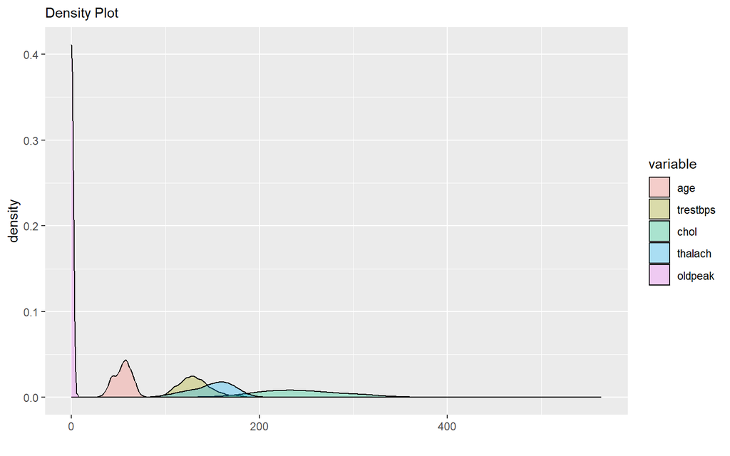

```r
set.seed(semilla)

#analisis univariado de los datos
d <- data.frame(data)

melt(d)%>%
  ggplot(aes(x=value, fill=variable)) +
  geom_density(alpha=0.3)+
  labs(x= "",
       subtitle="Density Plot")
```

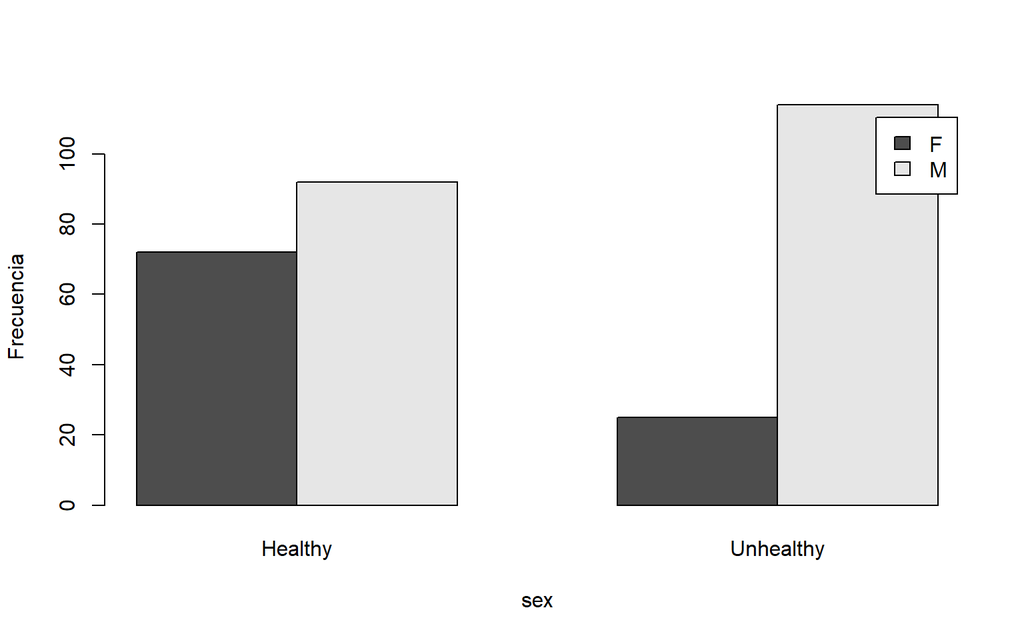

```r
set.seed(semilla)

# Variables categóricas en el conjunto de datos
covariables_categoricas <- c("sex")

# Variable respuesta en el conjunto de datos
variable_respuesta <- "num"

# Revisar la distribución bivariada para cada covariable categórica
for (covariable in covariables_categoricas) {
  # Tabla de contingencia
  tabla_contingencia <- table(data[[covariable]], data[[variable_respuesta]])

  # Gráfico de barras
  barplot(tabla_contingencia, beside = TRUE, legend.text = TRUE, xlab = covariable, ylab = "Frecuencia")
}
```

```r
set.seed(semilla)

# Tabla de contigencia sex ~ num
print(tabla_contingencia)
```

```
##
##     Healthy Unhealthy
##   F      72        25
##   M      92       114
```

```r
set.seed(semilla)

#cp: chest pain type
#        -- Value 1: typical angina
#        -- Value 2: atypical angina
#        -- Value 3: non-anginal pain
#        -- Value 4: asymptomatic

# Tabla de contigencia cp ~ num
tabla_contingencia2 <- table(data$cp, data$num)
tabla_contingencia2
```

```
##
##     Healthy Unhealthy
##   1      16         7
##   2      41         9
##   3      68        18
##   4      39       105
```

```r
set.seed(semilla)

#fbs: (fasting blood sugar > 120 mg/dl)  (1 = true; 0 = false)

# Tabla de contigencia fbs ~ num
tabla_contingencia3 <- table(data$fbs, data$num)
tabla_contingencia3
```

```
##
##         Healthy Unhealthy
##   False     141       117
##   True       23        22
```

```r
set.seed(semilla)

#restecg: resting electrocardiographic results
#        -- Value 0: normal
#        -- Value 1: having ST-T wave abnormality (T wave inversions and/or ST
#                    elevation or depression of > 0.05 mV)
#        -- Value 2: showing probable or definite left ventricular hypertrophy
#                    by Estes' criteria

# Tabla de contigencia restecg ~ num
tabla_contingencia4 <- table(data$restecg, data$num)
tabla_contingencia4
```

```
##
##     Healthy Unhealthy
##   0      95        56
##   1       1         3
##   2      68        80
```

## Punto 3: Modelo bivariado

```r
set.seed(semilla)

d$num <- ifelse(data$num == 0, yes = 0, no = 1)
logistic_model <- glm(fbs ~ num, data=data, family=binomial)
summary(logistic_model)$coefficients
```

```
##                Estimate Std. Error    z value     Pr(>|z|)
## (Intercept)  -1.8132657  0.2248787 -8.0633053 7.425878e-16
## numUnhealthy  0.1421342  0.3233759  0.4395324 6.602758e-01
```

## Punto 4: Modelo multivariado:

```r
set.seed(semilla)

#Modelo Multivariado con todas las variables
logistic_model <- glm(num ~ ., data = data, family = binomial)
summary(logistic_model)$coefficients
```

```
##                 Estimate  Std. Error    z value     Pr(>|z|)
## (Intercept) -6.360178762 2.959798060 -2.1488556 3.164584e-02
## age         -0.024628833 0.025119433 -0.9804693 3.268545e-01
## sexM         1.705566733 0.549410226  3.1043593 1.906916e-03
## cp.2         1.378119467 0.801650310  1.7191030 8.559562e-02
## cp.3         0.401815526 0.697482902  0.5760937 5.645518e-01
## cp.4         2.450529154 0.707253280  3.4648537 5.305200e-04
## trestbps     0.027699763 0.011725251  2.3624026 1.815691e-02
## chol         0.004343601 0.004120814  1.0540636 2.918538e-01
## fbsTrue     -0.377176485 0.564759331 -0.6678535 5.042271e-01
## restecg1     1.036881885 2.690193566  0.3854302 6.999187e-01
## restecg2     0.485676351 0.392791609  1.2364733 2.162827e-01
## thalach     -0.018825842 0.011699593 -1.6091023 1.075940e-01
## exangTrue    0.735619840 0.443279136  1.6594957 9.701594e-02
## oldpeak      0.398376176 0.238953491  1.6671704 9.548054e-02
## slope2       1.314502543 0.478527789  2.7469722 6.014823e-03
## slope3       0.588936081 0.945911409  0.6226123 5.335393e-01
## ca1          2.228216971 0.511914089  4.3527166 1.344609e-05
## ca2          3.261752143 0.786434326  4.1475201 3.360960e-05
## ca3          2.148739036 0.914676402  2.3491795 1.881484e-02
## thal6       -0.268720018 0.804929223 -0.3338430 7.384980e-01
## thal7        1.339207001 0.432243899  3.0982670 1.946560e-03
```

```r
set.seed(semilla)

# Obtener el resumen de los coeficientes del modelo
summary_coefs <- summary(logistic_model)$coefficients

# Filtrar las variables significativas según el test de Wald (valor de p < 0.05)
variables_significativas <- summary_coefs[summary_coefs[, "Pr(>|z|)"] < 0.05, ]

# Filtrar las variables no significativas según el test de Wald (valor de p >= 0.05)
variables_no_significativas <- summary_coefs[summary_coefs[, "Pr(>|z|)"] >= 0.05, ]

# Imprimir las variables significativas
cat("Variables significativas mediante el test de Wald:\n")
```

```
## Variables significativas mediante el test de Wald:
```

```r
print(variables_significativas)
```

```
##                Estimate Std. Error   z value     Pr(>|z|)
## (Intercept) -6.36017876 2.95979806 -2.148856 3.164584e-02
## sexM         1.70556673 0.54941023  3.104359 1.906916e-03
## cp.4         2.45052915 0.70725328  3.464854 5.305200e-04
## trestbps     0.02769976 0.01172525  2.362403 1.815691e-02
## slope2       1.31450254 0.47852779  2.746972 6.014823e-03
## ca1          2.22821697 0.51191409  4.352717 1.344609e-05
## ca2          3.26175214 0.78643433  4.147520 3.360960e-05
## ca3          2.14873904 0.91467640  2.349179 1.881484e-02
## thal7        1.33920700 0.43224390  3.098267 1.946560e-03
```

```r
cat("\n")
```

```r
cat("\n")
```

```r
# Imprimir las variables no significativas
cat("Variables no significativas mediante el test de Wald:\n")
```

```
## Variables no significativas mediante el test de Wald:
```

```r
print(variables_no_significativas)
```

```
##               Estimate  Std. Error    z value   Pr(>|z|)
## age       -0.024628833 0.025119433 -0.9804693 0.32685452
## cp.2       1.378119467 0.801650310  1.7191030 0.08559562
## cp.3       0.401815526 0.697482902  0.5760937 0.56455183
## chol       0.004343601 0.004120814  1.0540636 0.29185379
## fbsTrue   -0.377176485 0.564759331 -0.6678535 0.50422712
## restecg1   1.036881885 2.690193566  0.3854302 0.69991870
## restecg2   0.485676351 0.392791609  1.2364733 0.21628267
## thalach   -0.018825842 0.011699593 -1.6091023 0.10759398
## exangTrue  0.735619840 0.443279136  1.6594957 0.09701594
## oldpeak    0.398376176 0.238953491  1.6671704 0.09548054
## slope3     0.588936081 0.945911409  0.6226123 0.53353932
## thal6     -0.268720018 0.804929223 -0.3338430 0.73849800
```

```r
cat("\n")
```

```r
cat("\n")
```

## Punto 5: Visualización de probabilidades predichas bajo modelo multivariado

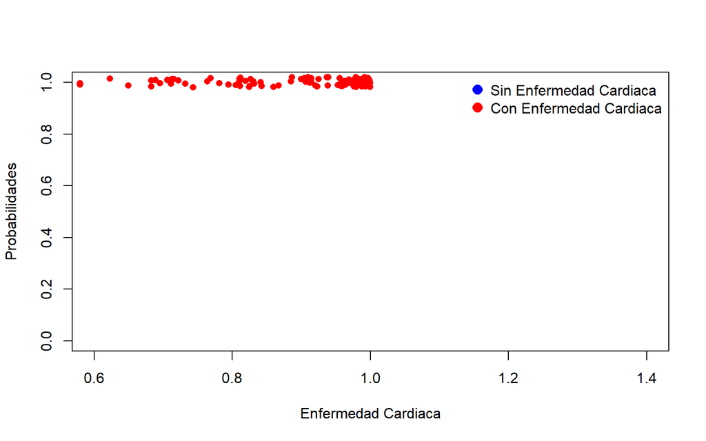

```r
set.seed(semilla)

# Obtener las probabilidades predichas
probabilidades_predichas <- predict(logistic_model, type = "response")

# Crear un nuevo dataframe con la variable respuesta y las probabilidades predichas
datos_probabilidades <- data.frame(Enfermedad_Cardiaca = d$num, Probabilidades = probabilidades_predichas)

# Graficar las probabilidades predichas junto a la variable respuesta
plot(Probabilidades ~ Enfermedad_Cardiaca, data = datos_probabilidades,
     type = "n", xlab = "Enfermedad Cardiaca", ylab = "Probabilidades")
points(jitter(Enfermedad_Cardiaca) ~ Probabilidades, data = datos_probabilidades,
       col = ifelse(Enfermedad_Cardiaca == 1, "red", "blue"), pch = 16, alpha = 0.5)
legend("topright", legend = c("Sin Enfermedad Cardiaca", "Con Enfermedad Cardiaca"),
       col = c("blue", "red"), pch = 16, pt.cex = 1.5, bty = "n")
```

# Problema 3

El conjunto de datos AAD-taller03.xlsx contiene la predicción de incumplimiento de pago de tarjeta de cr´edito bajo dos modelos log´ısticos diferentes para un total de 9080 clientes. Se cuenta además con la variable de incumplimiento observada al finalizar el periodo. ¿Cuál de los dos modelos logísticos tiene mayor poder de predicción? Explique con fundamento estad´ıstico su resultado.

```r
set.seed(semilla)

#carga de datos
datos <- read_excel('AAD-taller03.xlsx',sheet = 'Sheet1')
datos <-data.frame(datos)
```

```r
set.seed(semilla)

#visualización de datos
head(datos)
```

```
##   Incumplimiento ScoreLogisticoA ScoreLogisticoB
## 1              1       0.1379898            0.17
## 2              1       0.1224993            0.01
## 3              0       0.1177198            0.21
## 4              1       0.1158537            0.01
## 5              0       0.1111393            0.21
## 6              1       0.1046984            0.19
```

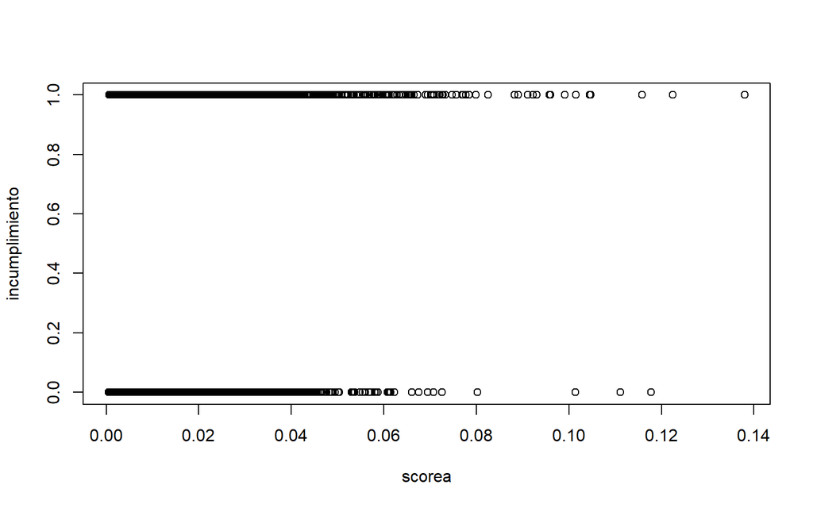

```r
set.seed(semilla)

scorea <- datos$ScoreLogisticoA
incumplimiento <- datos$Incumplimiento

plot(x= scorea,
     y= incumplimiento)
```

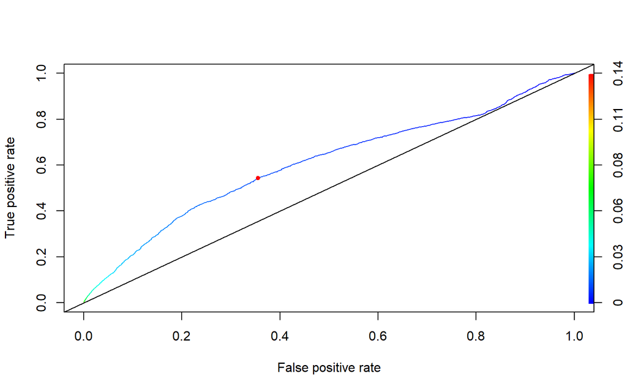

```r
set.seed(semilla)

pred <- prediction(datos$ScoreLogisticoA, datos$Incumplimiento)
perf <- performance(pred,measure="tpr",x.measure="fpr")

plot(perf,colorize=TRUE,type="l")
abline(a=0,b=1)

# Área bajo la curva
AUC       <- performance(pred,measure="auc")
AUCaltura <- AUC@y.values

# Punto de corte óptimo
cost.perf <- performance(pred, measure ="cost")
opt.cut   <- pred@cutoffs[[1]][which.min(cost.perf@y.values[[1]])]
#coordenadas del punto de corte óptimo
x<-perf@x.values[[1]][which.min(cost.perf@y.values[[1]])]
y<-perf@y.values[[1]][which.min(cost.perf@y.values[[1]])]
points(x,y, pch=20, col="red")
```

```r
set.seed(semilla)

cat("AUC:", AUCaltura[[1]])
```

```
## AUC: 0.6060437
```

```r
set.seed(semilla)

cat("Punto de corte óptimo:",opt.cut)
```

```
## Punto de corte óptimo: 0.01184178
```

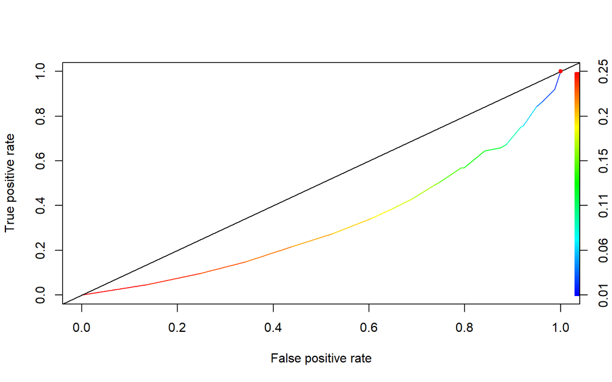

```r
set.seed(semilla)

pred <- prediction(datos$ScoreLogisticoB, datos$Incumplimiento)
perf <- performance(pred,measure="tpr",x.measure="fpr")

plot(perf,colorize=TRUE,type="l")
abline(a=0,b=1)

# Área bajo la curva
AUC       <- performance(pred,measure="auc")
AUCaltura <- AUC@y.values

# Punto de corte óptimo
cost.perf <- performance(pred, measure ="cost")
opt.cut   <- pred@cutoffs[[1]][which.min(cost.perf@y.values[[1]])]
#coordenadas del punto de corte óptimo
x<-perf@x.values[[1]][which.min(cost.perf@y.values[[1]])]
y<-perf@y.values[[1]][which.min(cost.perf@y.values[[1]])]
points(x,y, pch=20, col="red")
```

```r
set.seed(semilla)

cat("AUC:", AUCaltura[[1]])
```

```
## AUC: 0.3221364
```

```r
set.seed(semilla)

cat("Punto de corte óptimo:",opt.cut)
```

```
## Punto de corte óptimo: 0.01
```

De acuerdo a los datos, se evidencia que el primero modelo correspondiente al ScoreA es mejor que el modelo ScoreB, sin embargo la predicción en conjunto es baja dado que en el ScoreA el AUC 0.60 con punto de corte 0.01184178 y en el ScoreB el AUC 0.32 con punto de corte 0.01. Para mejorar los modelos antes mencionados, es necesario optimizar el poder de predicción de estos parametrizando los modelos logisticos

# Problema 4 (opcional)

Repita el problema 2, pero en lugar de imputar los datos mediante la mediana en el punto 1, utilice el algoritmo EM

```r
set.seed(semilla)

# Lectura del archivo
dataEM <- read.csv('processed.cleveland.data', na = '?', sep = ",", header = FALSE)

# Asignación de nombres de columnas
nombre_columna <- c("age", "sex", "cp", "trestbps", "chol", "fbs", "restecg", "thalach", "exang", "oldpeak", "slope", "ca", "thal", "num")
colnames(dataEM) <- nombre_columna
```

```r
set.seed(semilla)

#Conversión a factor, con el fin de trabajar con variables categoricas y nominales
dataEM$age <- as.numeric(dataEM$age)
dataEM$sex <- factor(dataEM$sex, levels = c(0, 1), labels = c("F", "M"))
dataEM$trestbps <- as.numeric(dataEM$trestbps)
dataEM$chol <- as.numeric(dataEM$chol)
dataEM$fbs <- factor(dataEM$fbs, levels = c(0, 1), labels = c("False", "True"))
dataEM$restecg <- factor(dataEM$restecg)
dataEM$thalach <- as.numeric(dataEM$thalach)
dataEM$exang <- factor(dataEM$exang, levels = c(0, 1), labels = c("False", "True"))
dataEM$oldpeak <- as.numeric(dataEM$oldpeak)
dataEM$slope <- factor(dataEM$slope)
dataEM$ca <- factor(dataEM$ca)
dataEM$thal <- factor(dataEM$thal)
dataEM$num <- ifelse(dataEM$num == 0, "Healthy", "Unhealthy")
```

```r
set.seed(semilla)

#visualizacion de datos, primero 10 registros
head(dataEM, 10)
```

```
##    age sex cp trestbps chol   fbs restecg thalach exang oldpeak slope ca thal
## 1   63   M  1      145  233  True       2     150 False     2.3     3  0    6
## 2   67   M  4      160  286 False       2     108  True     1.5     2  3    3
## 3   67   M  4      120  229 False       2     129  True     2.6     2  2    7
## 4   37   M  3      130  250 False       0     187 False     3.5     3  0    3
## 5   41   F  2      130  204 False       2     172 False     1.4     1  0    3
## 6   56   M  2      120  236 False       0     178 False     0.8     1  0    3
## 7   62   F  4      140  268 False       2     160 False     3.6     3  2    3
## 8   57   F  4      120  354 False       0     163  True     0.6     1  0    3
## 9   63   M  4      130  254 False       2     147 False     1.4     2  1    7
## 10  53   M  4      140  203  True       2     155  True     3.1     3  0    7
##          num
## 1    Healthy
## 2  Unhealthy
## 3  Unhealthy
## 4    Healthy
## 5    Healthy
## 6    Healthy
## 7  Unhealthy
## 8    Healthy
## 9  Unhealthy
## 10 Unhealthy
```

```r
set.seed(semilla)

#Cantidad de nulos luego de la imputación de datos
sum(is.na(dataEM))
```

```
## [1] 6
```

```r
set.seed(semilla)

#Ubicacion de los valores nulos en las columnas
sapply(dataEM, function(x)sum(is.na(x)))
```

```
##      age      sex       cp trestbps     chol      fbs  restecg  thalach
##        0        0        0        0        0        0        0        0
##    exang  oldpeak    slope       ca     thal      num
##        0        0        0        4        2        0
```

```r
set.seed(semilla)

# Imputación de valores perdidos utilizando el algoritmo EM
imp_data <- mice(dataEM)
# Obtenemos el conjunto completo de datos imputados
data_imputed <- complete(imp_data)
```

```r
# Establecemos la semilla
set.seed(semilla)

# Convertimos el resultado en un data frame
dataEM <- as.data.frame(data_imputed)
```

```r
set.seed(semilla)

# Perform EM algorithm for Gaussian Mixture Model estimation
gmm_model <- Mclust(dataEM, G = 2)  # Specify the desired number of components (clusters)

# Extract the estimated parameters from the GMM model
estimated_means <- gmm_model$parameters$mean
estimated_covariance <- gmm_model$parameters$cov

# Print the estimated means and covariance matrices
cat("\nEstimated Means:\n")
```

```
##
## Estimated Means:
```

```r
print(estimated_means)
```

```
##                [,1]        [,2]
## age       55.610843  53.5113704
## sex        1.880509   1.5210583
## cp         3.436231   2.9385213
## trestbps 134.385714 129.5558932
## chol     246.977314 246.4680863
## fbs        1.186704   1.1182877
## restecg    1.999979   1.9822792
## thalach  142.300121 155.3909565
## exang      1.507646   1.1835375
## oldpeak    1.484863   0.6871753
## slope      1.819412   1.4275153
## ca         1.934443   1.4547183
## thal       2.873987   1.0125984
## num        1.754795   1.2244189
```

```r
cat("\nEstimated Covariance Matrices:\n")
```

```
##
## Estimated Covariance Matrices:
```

```r
print(estimated_covariance)
```

[output not shown]

```r
set.seed(semilla)

dataEM$age <- as.numeric(dataEM$age)
dataEM$sex <- as.factor(dataEM$sex)
dataEM$trestbps <- as.numeric(dataEM$trestbps)
dataEM$chol <- as.numeric(dataEM$chol)
dataEM$fbs <- as.factor(dataEM$fbs)
dataEM$restecg <- as.factor(dataEM$restecg)
dataEM$thalach <- as.numeric(dataEM$thalach)
dataEM$exang <- as.factor(dataEM$exang)
dataEM$oldpeak <- as.numeric(dataEM$oldpeak)
dataEM$slope <- as.factor(dataEM$slope)
dataEM$ca <- as.factor(dataEM$ca)
dataEM$thal <- as.factor(dataEM$thal)
dataEM$num <- as.factor(dataEM$num)
```

```r
set.seed(semilla)

#Cantidad de nulos luego de la imputación de datos
sum(is.na(dataEM))
```

```
## [1] 0
```

## Punto 2: Revisar las distribuciones bivariadas

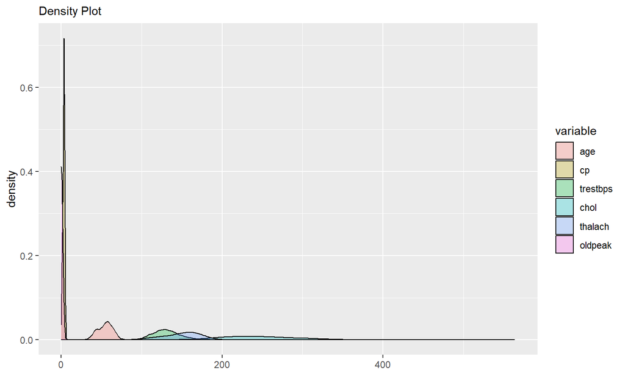

```r
set.seed(semilla)

#analisis univariado de los datos
d <- data.frame(dataEM)

melt(d)%>%
  ggplot(aes(x=value, fill=variable)) +
  geom_density(alpha=0.3)+
  labs(x= "",
       subtitle="Density Plot")
```

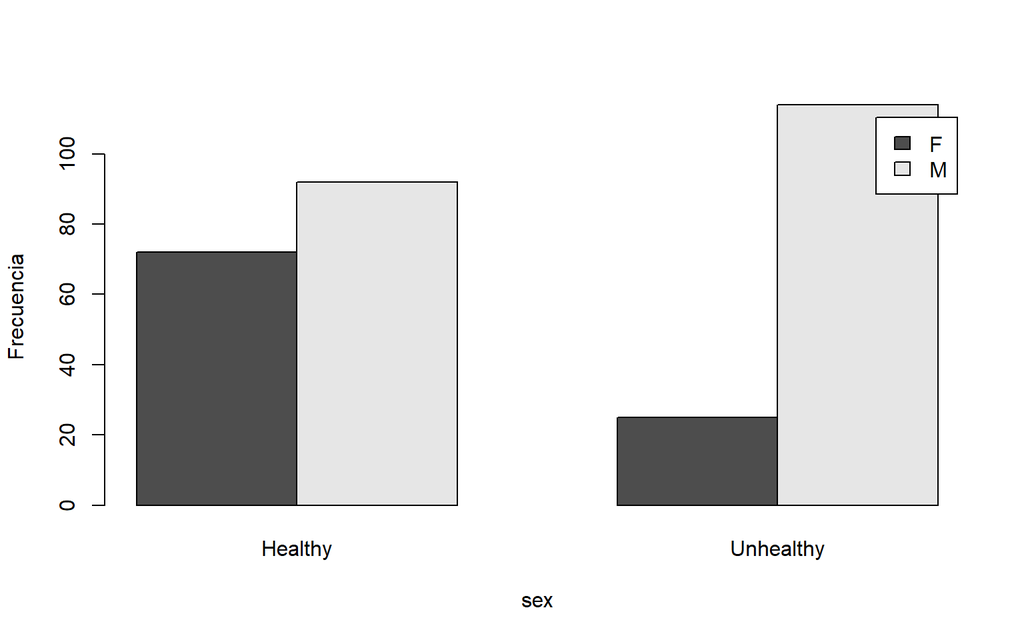

```r
set.seed(semilla)

# Variables categóricas en el conjunto de datos
covariables_categoricas <- c("sex")

# Variable respuesta en el conjunto de datos
variable_respuesta <- "num"

# Revisar la distribución bivariada para cada covariable categórica
for (covariable in covariables_categoricas) {
  # Tabla de contingencia
  tabla_contingencia <- table(dataEM[[covariable]], dataEM[[variable_respuesta]])

  # Gráfico de barras
  barplot(tabla_contingencia, beside = TRUE, legend.text = TRUE, xlab = covariable, ylab = "Frecuencia")
}
```

```r
set.seed(semilla)

# Tabla de contigencia sex ~ num
print(tabla_contingencia)
```

```
##
##     Healthy Unhealthy
##   F      72        25
##   M      92       114
```

```r
set.seed(semilla)

#cp: chest pain type
#        -- Value 1: typical angina
#        -- Value 2: atypical angina
#        -- Value 3: non-anginal pain
#        -- Value 4: asymptomatic

# Tabla de contigencia cp ~ num
tabla_contingencia2 <- table(dataEM$cp, dataEM$num)
tabla_contingencia2
```

```
##
##     Healthy Unhealthy
##   1      16         7
##   2      41         9
##   3      68        18
##   4      39       105
```

```r
set.seed(semilla)

#fbs: (fasting blood sugar > 120 mg/dl)  (1 = true; 0 = false)

# Tabla de contigencia fbs ~ num
tabla_contingencia3 <- table(dataEM$fbs, dataEM$num)
tabla_contingencia3
```

```
##
##         Healthy Unhealthy
##   False     141       117
##   True       23        22
```

```r
set.seed(semilla)

#restecg: resting electrocardiographic results
#        -- Value 0: normal
#        -- Value 1: having ST-T wave abnormality (T wave inversions and/or ST
#                    elevation or depression of > 0.05 mV)
#        -- Value 2: showing probable or definite left ventricular hypertrophy
#                    by Estes' criteria

# Tabla de contigencia restecg ~ num
tabla_contingencia4 <- table(dataEM$restecg, dataEM$num)
tabla_contingencia4
```

```
##
##     Healthy Unhealthy
##   0      95        56
##   1       1         3
##   2      68        80
```

## Punto 3: Modelo bivariado

```r
set.seed(semilla)

d$num <- ifelse(dataEM$num == 0, yes = 0, no = 1)
logistic_model <- glm(fbs ~ num, data=dataEM, family=binomial)
summary(logistic_model)$coefficients
```

```
##                Estimate Std. Error    z value     Pr(>|z|)
## (Intercept)  -1.8132657  0.2248787 -8.0633053 7.425878e-16
## numUnhealthy  0.1421342  0.3233759  0.4395324 6.602758e-01
```

## Punto 4: Modelo multivariado:

```r
set.seed(semilla)

#Modelo Multivariado con todas las variables
logistic_model <- glm(num ~ ., data = dataEM, family = binomial)
summary(logistic_model)$coefficients
```

```
##                Estimate  Std. Error    z value     Pr(>|z|)
## (Intercept) -6.55500339 2.873358966 -2.2813033 2.253050e-02
## age         -0.02568188 0.024386628 -1.0531131 2.922891e-01
## sexM         1.55124009 0.516163218  3.0053286 2.652941e-03
## cp           0.70807147 0.202667631  3.4937571 4.762742e-04
## trestbps     0.02750625 0.011189858  2.4581414 1.396582e-02
## chol         0.00452782 0.003827149  1.1830790 2.367778e-01
## fbsTrue     -0.62760533 0.529908591 -1.1843653 2.362685e-01
## restecg1     0.84200112 2.009147517  0.4190838 6.751549e-01
## restecg2     0.55550376 0.383145848  1.4498494 1.471005e-01
## thalach     -0.02017652 0.011064584 -1.8235229 6.822423e-02
## exangTrue    0.94300492 0.421005715  2.2398863 2.509831e-02
## oldpeak      0.26707198 0.216886927  1.2313881 2.181778e-01
## slope2       1.09715287 0.459704886  2.3866461 1.700285e-02
## slope3       0.51492809 0.887867300  0.5799606 5.619412e-01
## ca1          1.81616981 0.471893539  3.8486855 1.187534e-04
## ca2          3.38839723 0.748429142  4.5273454 5.972927e-06
## ca3          1.98514739 0.850971802  2.3328004 1.965862e-02
## thal6        0.33322254 0.781399306  0.4264434 6.697848e-01
## thal7        1.34329997 0.417079306  3.2207303 1.278644e-03
```

```r
set.seed(semilla)

# Obtener el resumen de los coeficientes del modelo
summary_coefs <- summary(logistic_model)$coefficients

# Filtrar las variables significativas según el test de Wald (valor de p < 0.05)
variables_significativas <- summary_coefs[summary_coefs[, "Pr(>|z|)"] < 0.05, ]

# Filtrar las variables no significativas según el test de Wald (valor de p >= 0.05)
variables_no_significativas <- summary_coefs[summary_coefs[, "Pr(>|z|)"] >= 0.05, ]

# Imprimir las variables significativas
cat("Variables significativas mediante el test de Wald:\n")
```

```
## Variables significativas mediante el test de Wald:
```

```r
print(variables_significativas)
```

```
##                Estimate Std. Error   z value     Pr(>|z|)
## (Intercept) -6.55500339 2.87335897 -2.281303 2.253050e-02
## sexM         1.55124009 0.51616322  3.005329 2.652941e-03
## cp           0.70807147 0.20266763  3.493757 4.762742e-04
## trestbps     0.02750625 0.01118986  2.458141 1.396582e-02
## exangTrue    0.94300492 0.42100572  2.239886 2.509831e-02
## slope2       1.09715287 0.45970489  2.386646 1.700285e-02
## ca1          1.81616981 0.47189354  3.848685 1.187534e-04
## ca2          3.38839723 0.74842914  4.527345 5.972927e-06
## ca3          1.98514739 0.85097180  2.332800 1.965862e-02
## thal7        1.34329997 0.41707931  3.220730 1.278644e-03
```

```r
cat("\n")
```

```r
cat("\n")
```

```r
# Imprimir las variables no significativas
cat("Variables no significativas mediante el test de Wald:\n")
```

```
## Variables no significativas mediante el test de Wald:
```

```r
print(variables_no_significativas)
```

```
##             Estimate  Std. Error    z value   Pr(>|z|)
## age      -0.02568188 0.024386628 -1.0531131 0.29228915
## chol      0.00452782 0.003827149  1.1830790 0.23677784
## fbsTrue  -0.62760533 0.529908591 -1.1843653 0.23626850
## restecg1  0.84200112 2.009147517  0.4190838 0.67515491
## restecg2  0.55550376 0.383145848  1.4498494 0.14710053
## thalach  -0.02017652 0.011064584 -1.8235229 0.06822423
## oldpeak   0.26707198 0.216886927  1.2313881 0.21817775
## slope3    0.51492809 0.887867300  0.5799606 0.56194116
## thal6     0.33322254 0.781399306  0.4264434 0.66978482
```

```r
cat("\n")
```

```r
cat("\n")
```

## Punto 5: Visualización de probabilidades predichas bajo modelo multivariado

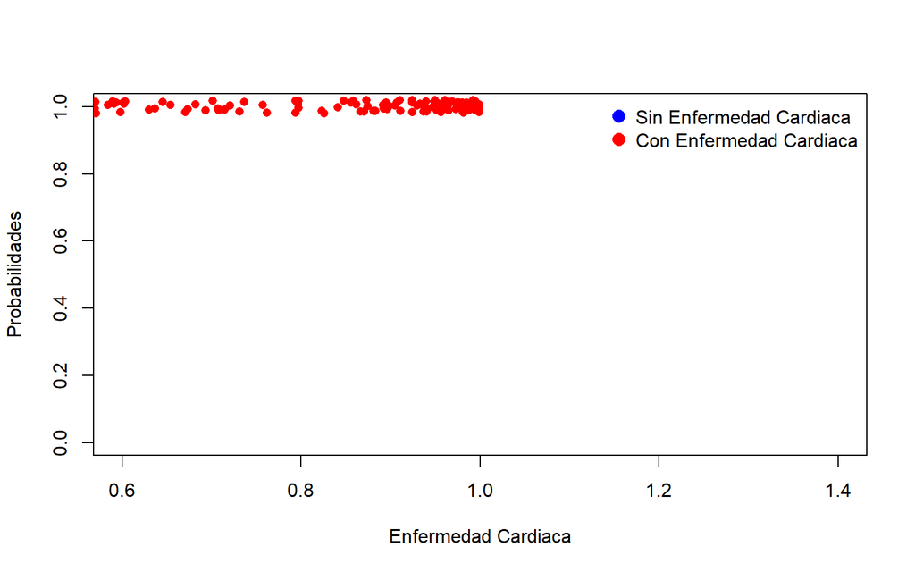

```r
set.seed(semilla)

# Obtener las probabilidades predichas
probabilidades_predichas <- predict(logistic_model, type = "response")

# Crear un nuevo dataframe con la variable respuesta y las probabilidades predichas
datos_probabilidades <- data.frame(Enfermedad_Cardiaca = d$num, Probabilidades = probabilidades_predichas)

# Graficar las probabilidades predichas junto a la variable respuesta
plot(Probabilidades ~ Enfermedad_Cardiaca, data = datos_probabilidades,
     type = "n", xlab = "Enfermedad Cardiaca", ylab = "Probabilidades")
points(jitter(Enfermedad_Cardiaca) ~ Probabilidades, data = datos_probabilidades,
       col = ifelse(Enfermedad_Cardiaca == 1, "red", "blue"), pch = 16, alpha = 0.5)
legend("topright", legend = c("Sin Enfermedad Cardiaca", "Con Enfermedad Cardiaca"),
       col = c("blue", "red"), pch = 16, pt.cex = 1.5, bty = "n")
```

Aplicando el algoritmo EM, se evidencia el mismo comportamiento de los datos como en el Problema 2

# Bibliografía

- Martínez Gutiérrez, A. (2017). *Análisis de las primas de riesgo en seguros de automóviles: una aplicación de los modelos lineales generalizados* (p. n583xt99h) [Maestro en Ciencias, Universidad Autónoma Metropolitana Unidad Iztapalapa]. [https://doi.org/10.24275/uami.n](https://doi.org/10.24275/uami.n583xt99h)e.12.637
- A, R. H., M, A. M., & C, D. M. (2012). Modelos de la Familia Exponencial. *Ingeniare*, *12*, Article 12. https://doi.org/10.18041/1909-2458/ingeniare.12.637
- Michael I. Jordan. The exponential family: Basics. 2009. URL https://people.eecs. berkeley.edu/~jordan/courses/260-spring10/other-readings/chapter8.pdf.